# Risk Factor Analysis

## Outcome Variable

**Outcome Variable:** ever_wasted

## Predictor Variables

**Intervention Variable:** gagebrth

**Adjustment Set:**

- arm
- sex
- W_mage
- meducyrs
- feducyrs
- hhwealth_quart
- single
- brthmon
- W_parity
- delta_W_mage
- delta_meducyrs
- delta_feducyrs
- delta_hhwealth_quart
- delta_single
- delta_brthmon
- delta_W_parity

## Stratifying Variables

The analysis was stratified on these variable(s):

- agecat
- studyid
- country

## Data Summary

| agecat | studyid | country | gagebrth | ever_wasted | n_cell | n |
| --- | --- | --- | --- | --- | --- | --- |
| 0-24 months (no birth wast) | ki1000108-CMC-V-BCS-2002 | INDIA | Full or late term | 0 | 123 | 348 |
| 0-24 months (no birth wast) | ki1000108-CMC-V-BCS-2002 | INDIA | Full or late term | 1 | 90 | 348 |
| 0-24 months (no birth wast) | ki1000108-CMC-V-BCS-2002 | INDIA | Preterm | 0 | 25 | 348 |
| 0-24 months (no birth wast) | ki1000108-CMC-V-BCS-2002 | INDIA | Preterm | 1 | 27 | 348 |
| 0-24 months (no birth wast) | ki1000108-CMC-V-BCS-2002 | INDIA | Early term | 0 | 46 | 348 |
| 0-24 months (no birth wast) | ki1000108-CMC-V-BCS-2002 | INDIA | Early term | 1 | 37 | 348 |
| 0-24 months (no birth wast) | ki1000108-IRC | INDIA | Full or late term | 0 | 121 | 389 |
| 0-24 months (no birth wast) | ki1000108-IRC | INDIA | Full or late term | 1 | 128 | 389 |
| 0-24 months (no birth wast) | ki1000108-IRC | INDIA | Preterm | 0 | 16 | 389 |
| 0-24 months (no birth wast) | ki1000108-IRC | INDIA | Preterm | 1 | 26 | 389 |
| 0-24 months (no birth wast) | ki1000108-IRC | INDIA | Early term | 0 | 44 | 389 |
| 0-24 months (no birth wast) | ki1000108-IRC | INDIA | Early term | 1 | 54 | 389 |
| 0-24 months (no birth wast) | ki1000109-EE | PAKISTAN | Full or late term | 0 | 19 | 377 |
| 0-24 months (no birth wast) | ki1000109-EE | PAKISTAN | Full or late term | 1 | 6 | 377 |
| 0-24 months (no birth wast) | ki1000109-EE | PAKISTAN | Preterm | 0 | 132 | 377 |
| 0-24 months (no birth wast) | ki1000109-EE | PAKISTAN | Preterm | 1 | 111 | 377 |
| 0-24 months (no birth wast) | ki1000109-EE | PAKISTAN | Early term | 0 | 61 | 377 |
| 0-24 months (no birth wast) | ki1000109-EE | PAKISTAN | Early term | 1 | 48 | 377 |
| 0-24 months (no birth wast) | ki1000304b-SAS-CompFeed | INDIA | Full or late term | 0 | 19 | 1487 |
| 0-24 months (no birth wast) | ki1000304b-SAS-CompFeed | INDIA | Full or late term | 1 | 9 | 1487 |
| 0-24 months (no birth wast) | ki1000304b-SAS-CompFeed | INDIA | Preterm | 0 | 862 | 1487 |
| 0-24 months (no birth wast) | ki1000304b-SAS-CompFeed | INDIA | Preterm | 1 | 496 | 1487 |
| 0-24 months (no birth wast) | ki1000304b-SAS-CompFeed | INDIA | Early term | 0 | 66 | 1487 |
| 0-24 months (no birth wast) | ki1000304b-SAS-CompFeed | INDIA | Early term | 1 | 35 | 1487 |
| 0-24 months (no birth wast) | ki1017093c-NIH-Crypto | BANGLADESH | Full or late term | 0 | 152 | 754 |
| 0-24 months (no birth wast) | ki1017093c-NIH-Crypto | BANGLADESH | Full or late term | 1 | 16 | 754 |
| 0-24 months (no birth wast) | ki1017093c-NIH-Crypto | BANGLADESH | Preterm | 0 | 214 | 754 |
| 0-24 months (no birth wast) | ki1017093c-NIH-Crypto | BANGLADESH | Preterm | 1 | 47 | 754 |
| 0-24 months (no birth wast) | ki1017093c-NIH-Crypto | BANGLADESH | Early term | 0 | 280 | 754 |
| 0-24 months (no birth wast) | ki1017093c-NIH-Crypto | BANGLADESH | Early term | 1 | 45 | 754 |

[output cut: 186 more lines]

The following strata were considered:

- agecat: 0-24 months (no birth wast), studyid: ki1000108-CMC-V-BCS-2002, country: INDIA
- agecat: 0-24 months (no birth wast), studyid: ki1000108-IRC, country: INDIA
- agecat: 0-24 months (no birth wast), studyid: ki1000109-EE, country: PAKISTAN
- agecat: 0-24 months (no birth wast), studyid: ki1000304b-SAS-CompFeed, country: INDIA
- agecat: 0-24 months (no birth wast), studyid: ki1017093c-NIH-Crypto, country: BANGLADESH
- agecat: 0-24 months (no birth wast), studyid: ki1066203-TanzaniaChild2, country: TANZANIA, UNITED REPUBLIC OF
- agecat: 0-24 months (no birth wast), studyid: ki1101329-Keneba, country: GAMBIA
- agecat: 0-24 months (no birth wast), studyid: ki1119695-PROBIT, country: BELARUS
- agecat: 0-24 months (no birth wast), studyid: ki1135781-COHORTS, country: GUATEMALA
- agecat: 0-24 months (no birth wast), studyid: ki1135781-COHORTS, country: INDIA
- agecat: 0-24 months (no birth wast), studyid: ki1135781-COHORTS, country: PHILIPPINES
- agecat: 0-24 months (no birth wast), studyid: kiGH5241-JiVitA-3, country: BANGLADESH
- agecat: 0-6 months (no birth wast), studyid: ki1000108-CMC-V-BCS-2002, country: INDIA
- agecat: 0-6 months (no birth wast), studyid: ki1000108-IRC, country: INDIA
- agecat: 0-6 months (no birth wast), studyid: ki1000109-EE, country: PAKISTAN
- agecat: 0-6 months (no birth wast), studyid: ki1000304b-SAS-CompFeed, country: INDIA
- agecat: 0-6 months (no birth wast), studyid: ki1017093c-NIH-Crypto, country: BANGLADESH
- agecat: 0-6 months (no birth wast), studyid: ki1066203-TanzaniaChild2, country: TANZANIA, UNITED REPUBLIC OF
- agecat: 0-6 months (no birth wast), studyid: ki1101329-Keneba, country: GAMBIA
- agecat: 0-6 months (no birth wast), studyid: ki1119695-PROBIT, country: BELARUS
- agecat: 0-6 months (no birth wast), studyid: ki1135781-COHORTS, country: GUATEMALA
- agecat: 0-6 months (no birth wast), studyid: ki1135781-COHORTS, country: INDIA
- agecat: 0-6 months (no birth wast), studyid: ki1135781-COHORTS, country: PHILIPPINES
- agecat: 0-6 months (no birth wast), studyid: kiGH5241-JiVitA-3, country: BANGLADESH
- agecat: 6-24 months, studyid: ki1000108-CMC-V-BCS-2002, country: INDIA
- agecat: 6-24 months, studyid: ki1000108-IRC, country: INDIA
- agecat: 6-24 months, studyid: ki1000109-EE, country: PAKISTAN
- agecat: 6-24 months, studyid: ki1000304b-SAS-CompFeed, country: INDIA
- agecat: 6-24 months, studyid: ki1017093c-NIH-Crypto, country: BANGLADESH
- agecat: 6-24 months, studyid: ki1066203-TanzaniaChild2, country: TANZANIA, UNITED REPUBLIC OF
- agecat: 6-24 months, studyid: ki1101329-Keneba, country: GAMBIA
- agecat: 6-24 months, studyid: ki1119695-PROBIT, country: BELARUS
- agecat: 6-24 months, studyid: ki1135781-COHORTS, country: GUATEMALA
- agecat: 6-24 months, studyid: ki1135781-COHORTS, country: INDIA
- agecat: 6-24 months, studyid: ki1135781-COHORTS, country: PHILIPPINES
- agecat: 6-24 months, studyid: kiGH5241-JiVitA-3, country: BANGLADESH

### Dropped Strata

Some strata were dropped due to rare outcomes:

- agecat: 0-6 months (no birth wast), studyid: ki1000109-EE, country: PAKISTAN
- agecat: 0-6 months (no birth wast), studyid: ki1000304b-SAS-CompFeed, country: INDIA
- agecat: 0-6 months (no birth wast), studyid: ki1135781-COHORTS, country: GUATEMALA
- agecat: 6-24 months, studyid: ki1000109-EE, country: PAKISTAN

## Methods Detail

We’re interested in the causal parameters $E[Y_a]$ for all values of $a \in \mathcal{A}$. These parameters represent the mean outcome if, possibly contrary to fact, we intervened to set all units to have $A=a$. Under the randomization and positivity assumptions, these are identified by the statistical parameters $\psi_a=E_W[E_{Y|A,W}(Y|A=a,W)]$. In addition, we’re interested in the mean of $Y$, $E[Y]$ under no intervention (the observed mean). We will estimate these parameters by using SuperLearner to fit the relevant likelihood factors – $E_{Y|A,W}(Y|A=a,W)$ and $p(A=a|W)$, and then updating our likelihood fit using a joint TMLE.

For unadjusted analyses ($W=\{\}$), initial likelihoods were estimated using Lrnr_glm to estimate the simple $E(Y|A)$ and Lrnr_mean to estimate $p(A)$. For adjusted analyses, a small library containing Lrnr_glmnet, Lrnr_xgboost, and Lrnr_mean was used.

Having estimated these parameters, we will then use the delta method to estimate relative risks and attributable risks relative to a prespecified baseline level of $A$.

# Results Detail

## Results Plots

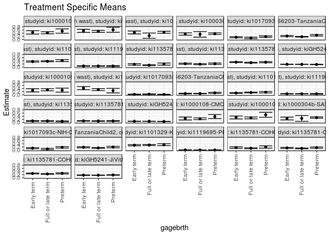

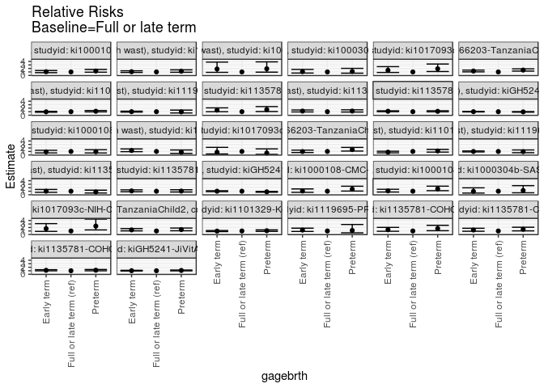

[figure not shown]

[figure not shown]

## Results Table

### Parameter: TSM

| agecat | studyid | country | intervention_level | baseline_level | estimate | ci_lower | ci_upper |
| --- | --- | --- | --- | --- | --- | --- | --- |
| 0-24 months (no birth wast) | ki1000108-CMC-V-BCS-2002 | INDIA | Full or late term | NA | 0.4237275 | 0.3571723 | 0.4902826 |
| 0-24 months (no birth wast) | ki1000108-CMC-V-BCS-2002 | INDIA | Preterm | NA | 0.5337415 | 0.3957133 | 0.6717698 |
| 0-24 months (no birth wast) | ki1000108-CMC-V-BCS-2002 | INDIA | Early term | NA | 0.4496543 | 0.3421379 | 0.5571707 |
| 0-24 months (no birth wast) | ki1000108-IRC | INDIA | Full or late term | NA | 0.5152275 | 0.4530117 | 0.5774434 |
| 0-24 months (no birth wast) | ki1000108-IRC | INDIA | Preterm | NA | 0.6184963 | 0.4592759 | 0.7777167 |
| 0-24 months (no birth wast) | ki1000108-IRC | INDIA | Early term | NA | 0.5471454 | 0.4466022 | 0.6476885 |
| 0-24 months (no birth wast) | ki1000109-EE | PAKISTAN | Full or late term | NA | 0.2400000 | 0.0723640 | 0.4076360 |
| 0-24 months (no birth wast) | ki1000109-EE | PAKISTAN | Preterm | NA | 0.4567901 | 0.3940762 | 0.5195040 |
| 0-24 months (no birth wast) | ki1000109-EE | PAKISTAN | Early term | NA | 0.4403670 | 0.3470479 | 0.5336861 |
| 0-24 months (no birth wast) | ki1000304b-SAS-CompFeed | INDIA | Full or late term | NA | 0.3214286 | 0.1438525 | 0.4990046 |
| 0-24 months (no birth wast) | ki1000304b-SAS-CompFeed | INDIA | Preterm | NA | 0.3652430 | 0.3139329 | 0.4165531 |
| 0-24 months (no birth wast) | ki1000304b-SAS-CompFeed | INDIA | Early term | NA | 0.3465347 | 0.2741080 | 0.4189613 |
| 0-24 months (no birth wast) | ki1017093c-NIH-Crypto | BANGLADESH | Full or late term | NA | 0.0944114 | 0.0503725 | 0.1384504 |
| 0-24 months (no birth wast) | ki1017093c-NIH-Crypto | BANGLADESH | Preterm | NA | 0.1805800 | 0.1336964 | 0.2274636 |
| 0-24 months (no birth wast) | ki1017093c-NIH-Crypto | BANGLADESH | Early term | NA | 0.1385169 | 0.1007612 | 0.1762726 |
| 0-24 months (no birth wast) | ki1066203-TanzaniaChild2 | TANZANIA, UNITED REPUBLIC OF | Full or late term | NA | 0.1734909 | 0.1535525 | 0.1934293 |
| 0-24 months (no birth wast) | ki1066203-TanzaniaChild2 | TANZANIA, UNITED REPUBLIC OF | Preterm | NA | 0.2656092 | 0.2190838 | 0.3121347 |
| 0-24 months (no birth wast) | ki1066203-TanzaniaChild2 | TANZANIA, UNITED REPUBLIC OF | Early term | NA | 0.2168523 | 0.1809863 | 0.2527183 |
| 0-24 months (no birth wast) | ki1101329-Keneba | GAMBIA | Full or late term | NA | 0.3703374 | 0.3378066 | 0.4028681 |
| 0-24 months (no birth wast) | ki1101329-Keneba | GAMBIA | Preterm | NA | 0.4170409 | 0.3555052 | 0.4785766 |
| 0-24 months (no birth wast) | ki1101329-Keneba | GAMBIA | Early term | NA | 0.3557285 | 0.3175344 | 0.3939227 |
| 0-24 months (no birth wast) | ki1119695-PROBIT | BELARUS | Full or late term | NA | 0.0714813 | 0.0584760 | 0.0844866 |
| 0-24 months (no birth wast) | ki1119695-PROBIT | BELARUS | Preterm | NA | 0.0684792 | 0.0385881 | 0.0983704 |
| 0-24 months (no birth wast) | ki1119695-PROBIT | BELARUS | Early term | NA | 0.0722204 | 0.0591673 | 0.0852735 |
| 0-24 months (no birth wast) | ki1135781-COHORTS | GUATEMALA | Full or late term | NA | 0.1208106 | 0.0905064 | 0.1511149 |
| 0-24 months (no birth wast) | ki1135781-COHORTS | GUATEMALA | Preterm | NA | 0.1934373 | 0.1256057 | 0.2612690 |
| 0-24 months (no birth wast) | ki1135781-COHORTS | GUATEMALA | Early term | NA | 0.1736151 | 0.1243823 | 0.2228478 |
| 0-24 months (no birth wast) | ki1135781-COHORTS | INDIA | Full or late term | NA | 0.1847528 | 0.1530210 | 0.2164846 |
| 0-24 months (no birth wast) | ki1135781-COHORTS | INDIA | Preterm | NA | 0.2183251 | 0.1729937 | 0.2636565 |
| 0-24 months (no birth wast) | ki1135781-COHORTS | INDIA | Early term | NA | 0.2175634 | 0.1800131 | 0.2551137 |

[output cut: 66 more lines]

### Parameter: E(Y)

| agecat | studyid | country | intervention_level | baseline_level | estimate | ci_lower | ci_upper |
| --- | --- | --- | --- | --- | --- | --- | --- |
| 0-24 months (no birth wast) | ki1000108-CMC-V-BCS-2002 | INDIA | NA | NA | 0.4425287 | 0.3902692 | 0.4947882 |
| 0-24 months (no birth wast) | ki1000108-IRC | INDIA | NA | NA | 0.5347044 | 0.4850733 | 0.5843354 |
| 0-24 months (no birth wast) | ki1000109-EE | PAKISTAN | NA | NA | 0.4376658 | 0.3875213 | 0.4878102 |
| 0-24 months (no birth wast) | ki1000304b-SAS-CompFeed | INDIA | NA | NA | 0.3631473 | 0.3130392 | 0.4132554 |
| 0-24 months (no birth wast) | ki1017093c-NIH-Crypto | BANGLADESH | NA | NA | 0.1432361 | 0.1182149 | 0.1682572 |
| 0-24 months (no birth wast) | ki1066203-TanzaniaChild2 | TANZANIA, UNITED REPUBLIC OF | NA | NA | 0.1975914 | 0.1811057 | 0.2140772 |
| 0-24 months (no birth wast) | ki1101329-Keneba | GAMBIA | NA | NA | 0.3725606 | 0.3495097 | 0.3956116 |
| 0-24 months (no birth wast) | ki1119695-PROBIT | BELARUS | NA | NA | 0.0716952 | 0.0597165 | 0.0836739 |
| 0-24 months (no birth wast) | ki1135781-COHORTS | GUATEMALA | NA | NA | 0.1470952 | 0.1226726 | 0.1715178 |
| 0-24 months (no birth wast) | ki1135781-COHORTS | INDIA | NA | NA | 0.2044610 | 0.1828992 | 0.2260227 |
| 0-24 months (no birth wast) | ki1135781-COHORTS | PHILIPPINES | NA | NA | 0.3030404 | 0.2865732 | 0.3195077 |
| 0-24 months (no birth wast) | kiGH5241-JiVitA-3 | BANGLADESH | NA | NA | 0.1756674 | 0.1694118 | 0.1819231 |
| 0-6 months (no birth wast) | ki1000108-CMC-V-BCS-2002 | INDIA | NA | NA | 0.3072289 | 0.2575285 | 0.3569293 |
| 0-6 months (no birth wast) | ki1000108-IRC | INDIA | NA | NA | 0.3477089 | 0.2991827 | 0.3962350 |
| 0-6 months (no birth wast) | ki1017093c-NIH-Crypto | BANGLADESH | NA | NA | 0.0267023 | 0.0151493 | 0.0382553 |
| 0-6 months (no birth wast) | ki1066203-TanzaniaChild2 | TANZANIA, UNITED REPUBLIC OF | NA | NA | 0.0859445 | 0.0743193 | 0.0975697 |
| 0-6 months (no birth wast) | ki1101329-Keneba | GAMBIA | NA | NA | 0.1365979 | 0.1195068 | 0.1536891 |
| 0-6 months (no birth wast) | ki1119695-PROBIT | BELARUS | NA | NA | 0.0637570 | 0.0524446 | 0.0750694 |
| 0-6 months (no birth wast) | ki1135781-COHORTS | INDIA | NA | NA | 0.0864692 | 0.0708761 | 0.1020623 |
| 0-6 months (no birth wast) | ki1135781-COHORTS | PHILIPPINES | NA | NA | 0.0942127 | 0.0837084 | 0.1047169 |
| 0-6 months (no birth wast) | kiGH5241-JiVitA-3 | BANGLADESH | NA | NA | 0.0743146 | 0.0700205 | 0.0786087 |
| 6-24 months | ki1000108-CMC-V-BCS-2002 | INDIA | NA | NA | 0.2592593 | 0.2133485 | 0.3051700 |
| 6-24 months | ki1000108-IRC | INDIA | NA | NA | 0.3179487 | 0.2716722 | 0.3642252 |
| 6-24 months | ki1000304b-SAS-CompFeed | INDIA | NA | NA | 0.3060189 | 0.2640311 | 0.3480066 |
| 6-24 months | ki1017093c-NIH-Crypto | BANGLADESH | NA | NA | 0.1315068 | 0.1069744 | 0.1560393 |
| 6-24 months | ki1066203-TanzaniaChild2 | TANZANIA, UNITED REPUBLIC OF | NA | NA | 0.1591987 | 0.1427306 | 0.1756669 |
| 6-24 months | ki1101329-Keneba | GAMBIA | NA | NA | 0.3247706 | 0.3020649 | 0.3474764 |
| 6-24 months | ki1119695-PROBIT | BELARUS | NA | NA | 0.0100615 | 0.0072668 | 0.0128561 |
| 6-24 months | ki1135781-COHORTS | GUATEMALA | NA | NA | 0.1443433 | 0.1194882 | 0.1691984 |
| 6-24 months | ki1135781-COHORTS | INDIA | NA | NA | 0.1318764 | 0.1136647 | 0.1500881 |
| 6-24 months | ki1135781-COHORTS | PHILIPPINES | NA | NA | 0.2669537 | 0.2505274 | 0.2833801 |
| 6-24 months | kiGH5241-JiVitA-3 | BANGLADESH | NA | NA | 0.1700055 | 0.1628870 | 0.1771239 |

### Parameter: RR

| agecat | studyid | country | intervention_level | baseline_level | estimate | ci_lower | ci_upper |
| --- | --- | --- | --- | --- | --- | --- | --- |
| 0-24 months (no birth wast) | ki1000108-CMC-V-BCS-2002 | INDIA | Full or late term | Full or late term | 1.0000000 | 1.0000000 | 1.0000000 |
| 0-24 months (no birth wast) | ki1000108-CMC-V-BCS-2002 | INDIA | Preterm | Full or late term | 1.2596340 | 0.9304798 | 1.7052255 |
| 0-24 months (no birth wast) | ki1000108-CMC-V-BCS-2002 | INDIA | Early term | Full or late term | 1.0611874 | 0.7968240 | 1.4132591 |
| 0-24 months (no birth wast) | ki1000108-IRC | INDIA | Full or late term | Full or late term | 1.0000000 | 1.0000000 | 1.0000000 |
| 0-24 months (no birth wast) | ki1000108-IRC | INDIA | Preterm | Full or late term | 1.2004333 | 0.9029090 | 1.5959971 |
| 0-24 months (no birth wast) | ki1000108-IRC | INDIA | Early term | Full or late term | 1.0619490 | 0.8522892 | 1.3231843 |
| 0-24 months (no birth wast) | ki1000109-EE | PAKISTAN | Full or late term | Full or late term | 1.0000000 | 1.0000000 | 1.0000000 |
| 0-24 months (no birth wast) | ki1000109-EE | PAKISTAN | Preterm | Full or late term | 1.9032922 | 0.9340145 | 3.8784420 |
| 0-24 months (no birth wast) | ki1000109-EE | PAKISTAN | Early term | Full or late term | 1.8348624 | 0.8843059 | 3.8071892 |
| 0-24 months (no birth wast) | ki1000304b-SAS-CompFeed | INDIA | Full or late term | Full or late term | 1.0000000 | 1.0000000 | 1.0000000 |
| 0-24 months (no birth wast) | ki1000304b-SAS-CompFeed | INDIA | Preterm | Full or late term | 1.1363116 | 0.6396536 | 2.0185988 |
| 0-24 months (no birth wast) | ki1000304b-SAS-CompFeed | INDIA | Early term | Full or late term | 1.0781078 | 0.6775643 | 1.7154334 |
| 0-24 months (no birth wast) | ki1017093c-NIH-Crypto | BANGLADESH | Full or late term | Full or late term | 1.0000000 | 1.0000000 | 1.0000000 |
| 0-24 months (no birth wast) | ki1017093c-NIH-Crypto | BANGLADESH | Preterm | Full or late term | 1.9126922 | 1.1214779 | 3.2621164 |
| 0-24 months (no birth wast) | ki1017093c-NIH-Crypto | BANGLADESH | Early term | Full or late term | 1.4671628 | 0.8547610 | 2.5183258 |
| 0-24 months (no birth wast) | ki1066203-TanzaniaChild2 | TANZANIA, UNITED REPUBLIC OF | Full or late term | Full or late term | 1.0000000 | 1.0000000 | 1.0000000 |
| 0-24 months (no birth wast) | ki1066203-TanzaniaChild2 | TANZANIA, UNITED REPUBLIC OF | Preterm | Full or late term | 1.5309693 | 1.2419096 | 1.8873089 |
| 0-24 months (no birth wast) | ki1066203-TanzaniaChild2 | TANZANIA, UNITED REPUBLIC OF | Early term | Full or late term | 1.2499349 | 1.0217123 | 1.5291362 |
| 0-24 months (no birth wast) | ki1101329-Keneba | GAMBIA | Full or late term | Full or late term | 1.0000000 | 1.0000000 | 1.0000000 |
| 0-24 months (no birth wast) | ki1101329-Keneba | GAMBIA | Preterm | Full or late term | 1.1261107 | 0.9486754 | 1.3367327 |
| 0-24 months (no birth wast) | ki1101329-Keneba | GAMBIA | Early term | Full or late term | 0.9605526 | 0.8368938 | 1.1024831 |
| 0-24 months (no birth wast) | ki1119695-PROBIT | BELARUS | Full or late term | Full or late term | 1.0000000 | 1.0000000 | 1.0000000 |
| 0-24 months (no birth wast) | ki1119695-PROBIT | BELARUS | Preterm | Full or late term | 0.9580025 | 0.6302736 | 1.4561437 |
| 0-24 months (no birth wast) | ki1119695-PROBIT | BELARUS | Early term | Full or late term | 1.0103406 | 0.8841310 | 1.1545666 |
| 0-24 months (no birth wast) | ki1135781-COHORTS | GUATEMALA | Full or late term | Full or late term | 1.0000000 | 1.0000000 | 1.0000000 |
| 0-24 months (no birth wast) | ki1135781-COHORTS | GUATEMALA | Preterm | Full or late term | 1.6011618 | 1.0402052 | 2.4646283 |
| 0-24 months (no birth wast) | ki1135781-COHORTS | GUATEMALA | Early term | Full or late term | 1.4370846 | 0.9841921 | 2.0983834 |
| 0-24 months (no birth wast) | ki1135781-COHORTS | INDIA | Full or late term | Full or late term | 1.0000000 | 1.0000000 | 1.0000000 |
| 0-24 months (no birth wast) | ki1135781-COHORTS | INDIA | Preterm | Full or late term | 1.1817143 | 0.9037279 | 1.5452094 |
| 0-24 months (no birth wast) | ki1135781-COHORTS | INDIA | Early term | Full or late term | 1.1775916 | 0.9242973 | 1.5002986 |

[output cut: 66 more lines]

### Parameter: PAR

| agecat | studyid | country | intervention_level | baseline_level | estimate | ci_lower | ci_upper |
| --- | --- | --- | --- | --- | --- | --- | --- |
| 0-24 months (no birth wast) | ki1000108-CMC-V-BCS-2002 | INDIA | Full or late term | NA | 0.0188013 | -0.0230963 | 0.0606988 |
| 0-24 months (no birth wast) | ki1000108-IRC | INDIA | Full or late term | NA | 0.0194768 | -0.0180359 | 0.0569896 |
| 0-24 months (no birth wast) | ki1000109-EE | PAKISTAN | Full or late term | NA | 0.1976658 | 0.0336863 | 0.3616452 |
| 0-24 months (no birth wast) | ki1000304b-SAS-CompFeed | INDIA | Full or late term | NA | 0.0417187 | -0.1370436 | 0.2204810 |
| 0-24 months (no birth wast) | ki1017093c-NIH-Crypto | BANGLADESH | Full or late term | NA | 0.0488246 | 0.0076496 | 0.0899997 |
| 0-24 months (no birth wast) | ki1066203-TanzaniaChild2 | TANZANIA, UNITED REPUBLIC OF | Full or late term | NA | 0.0241005 | 0.0107508 | 0.0374502 |
| 0-24 months (no birth wast) | ki1101329-Keneba | GAMBIA | Full or late term | NA | 0.0022232 | -0.0208478 | 0.0252943 |
| 0-24 months (no birth wast) | ki1119695-PROBIT | BELARUS | Full or late term | NA | 0.0002139 | -0.0041974 | 0.0046253 |
| 0-24 months (no birth wast) | ki1135781-COHORTS | GUATEMALA | Full or late term | NA | 0.0262846 | 0.0038840 | 0.0486851 |
| 0-24 months (no birth wast) | ki1135781-COHORTS | INDIA | Full or late term | NA | 0.0197081 | -0.0046289 | 0.0440451 |
| 0-24 months (no birth wast) | ki1135781-COHORTS | PHILIPPINES | Full or late term | NA | 0.0198998 | -0.0006740 | 0.0404736 |
| 0-24 months (no birth wast) | kiGH5241-JiVitA-3 | BANGLADESH | Full or late term | NA | -0.0017738 | -0.0073993 | 0.0038518 |
| 0-6 months (no birth wast) | ki1000108-CMC-V-BCS-2002 | INDIA | Full or late term | NA | -0.0126505 | -0.0530901 | 0.0277891 |
| 0-6 months (no birth wast) | ki1000108-IRC | INDIA | Full or late term | NA | 0.0171834 | -0.0194735 | 0.0538403 |
| 0-6 months (no birth wast) | ki1017093c-NIH-Crypto | BANGLADESH | Full or late term | NA | -0.0090120 | -0.0328503 | 0.0148263 |
| 0-6 months (no birth wast) | ki1066203-TanzaniaChild2 | TANZANIA, UNITED REPUBLIC OF | Full or late term | NA | 0.0062150 | -0.0031484 | 0.0155784 |
| 0-6 months (no birth wast) | ki1101329-Keneba | GAMBIA | Full or late term | NA | -0.0072056 | -0.0248326 | 0.0104215 |
| 0-6 months (no birth wast) | ki1119695-PROBIT | BELARUS | Full or late term | NA | -0.0003058 | -0.0044733 | 0.0038617 |
| 0-6 months (no birth wast) | ki1135781-COHORTS | INDIA | Full or late term | NA | -0.0050453 | -0.0232591 | 0.0131685 |
| 0-6 months (no birth wast) | ki1135781-COHORTS | PHILIPPINES | Full or late term | NA | 0.0040204 | -0.0091431 | 0.0171839 |
| 0-6 months (no birth wast) | kiGH5241-JiVitA-3 | BANGLADESH | Full or late term | NA | -0.0027817 | -0.0065019 | 0.0009384 |
| 6-24 months | ki1000108-CMC-V-BCS-2002 | INDIA | Full or late term | NA | 0.0225124 | -0.0147882 | 0.0598130 |
| 6-24 months | ki1000108-IRC | INDIA | Full or late term | NA | 0.0269497 | -0.0086420 | 0.0625414 |
| 6-24 months | ki1000304b-SAS-CompFeed | INDIA | Full or late term | NA | 0.0467596 | -0.1497850 | 0.2433042 |
| 6-24 months | ki1017093c-NIH-Crypto | BANGLADESH | Full or late term | NA | 0.0573650 | 0.0181774 | 0.0965527 |
| 6-24 months | ki1066203-TanzaniaChild2 | TANZANIA, UNITED REPUBLIC OF | Full or late term | NA | 0.0193737 | 0.0057602 | 0.0329872 |
| 6-24 months | ki1101329-Keneba | GAMBIA | Full or late term | NA | 0.0007873 | -0.0217908 | 0.0233655 |
| 6-24 months | ki1119695-PROBIT | BELARUS | Full or late term | NA | 0.0010981 | -0.0006579 | 0.0028542 |
| 6-24 months | ki1135781-COHORTS | GUATEMALA | Full or late term | NA | 0.0249709 | 0.0022944 | 0.0476474 |
| 6-24 months | ki1135781-COHORTS | INDIA | Full or late term | NA | 0.0223981 | 0.0020297 | 0.0427665 |
| 6-24 months | ki1135781-COHORTS | PHILIPPINES | Full or late term | NA | 0.0213286 | 0.0009382 | 0.0417190 |
| 6-24 months | kiGH5241-JiVitA-3 | BANGLADESH | Full or late term | NA | 0.0036149 | -0.0032664 | 0.0104962 |

### Parameter: PAF

| agecat | studyid | country | intervention_level | baseline_level | estimate | ci_lower | ci_upper |
| --- | --- | --- | --- | --- | --- | --- | --- |
| 0-24 months (no birth wast) | ki1000108-CMC-V-BCS-2002 | INDIA | Full or late term | NA | 0.0424860 | -0.0571054 | 0.1326947 |
| 0-24 months (no birth wast) | ki1000108-IRC | INDIA | Full or late term | NA | 0.0364254 | -0.0364356 | 0.1041644 |
| 0-24 months (no birth wast) | ki1000109-EE | PAKISTAN | Full or late term | NA | 0.4516364 | -0.0848875 | 0.7228259 |
| 0-24 months (no birth wast) | ki1000304b-SAS-CompFeed | INDIA | Full or late term | NA | 0.1148810 | -0.5395125 | 0.4911144 |
| 0-24 months (no birth wast) | ki1017093c-NIH-Crypto | BANGLADESH | Full or late term | NA | 0.3408684 | -0.0119056 | 0.5706571 |
| 0-24 months (no birth wast) | ki1066203-TanzaniaChild2 | TANZANIA, UNITED REPUBLIC OF | Full or late term | NA | 0.1219716 | 0.0522257 | 0.1865850 |
| 0-24 months (no birth wast) | ki1101329-Keneba | GAMBIA | Full or late term | NA | 0.0059675 | -0.0579269 | 0.0660029 |
| 0-24 months (no birth wast) | ki1119695-PROBIT | BELARUS | Full or late term | NA | 0.0029840 | -0.0605170 | 0.0626826 |
| 0-24 months (no birth wast) | ki1135781-COHORTS | GUATEMALA | Full or late term | NA | 0.1786908 | 0.0137776 | 0.3160278 |
| 0-24 months (no birth wast) | ki1135781-COHORTS | INDIA | Full or late term | NA | 0.0963907 | -0.0307745 | 0.2078677 |
| 0-24 months (no birth wast) | ki1135781-COHORTS | PHILIPPINES | Full or late term | NA | 0.0656671 | -0.0047401 | 0.1311406 |
| 0-24 months (no birth wast) | kiGH5241-JiVitA-3 | BANGLADESH | Full or late term | NA | -0.0100972 | -0.0426374 | 0.0214274 |
| 0-6 months (no birth wast) | ki1000108-CMC-V-BCS-2002 | INDIA | Full or late term | NA | -0.0411761 | -0.1814515 | 0.0824442 |
| 0-6 months (no birth wast) | ki1000108-IRC | INDIA | Full or late term | NA | 0.0494190 | -0.0620385 | 0.1491794 |
| 0-6 months (no birth wast) | ki1017093c-NIH-Crypto | BANGLADESH | Full or late term | NA | -0.3375000 | -1.5855791 | 0.3081216 |
| 0-6 months (no birth wast) | ki1066203-TanzaniaChild2 | TANZANIA, UNITED REPUBLIC OF | Full or late term | NA | 0.0723144 | -0.0428988 | 0.1747995 |
| 0-6 months (no birth wast) | ki1101329-Keneba | GAMBIA | Full or late term | NA | -0.0527503 | -0.1897763 | 0.0684944 |
| 0-6 months (no birth wast) | ki1119695-PROBIT | BELARUS | Full or late term | NA | -0.0047969 | -0.0721559 | 0.0583302 |
| 0-6 months (no birth wast) | ki1135781-COHORTS | INDIA | Full or late term | NA | -0.0583480 | -0.2911155 | 0.1324552 |
| 0-6 months (no birth wast) | ki1135781-COHORTS | PHILIPPINES | Full or late term | NA | 0.0426733 | -0.1076726 | 0.1726125 |
| 0-6 months (no birth wast) | kiGH5241-JiVitA-3 | BANGLADESH | Full or late term | NA | -0.0374317 | -0.0884997 | 0.0112404 |
| 6-24 months | ki1000108-CMC-V-BCS-2002 | INDIA | Full or late term | NA | 0.0868334 | -0.0686799 | 0.2197166 |
| 6-24 months | ki1000108-IRC | INDIA | Full or late term | NA | 0.0847611 | -0.0343044 | 0.1901203 |
| 6-24 months | ki1000304b-SAS-CompFeed | INDIA | Full or late term | NA | 0.1527997 | -0.7914569 | 0.5993494 |
| 6-24 months | ki1017093c-NIH-Crypto | BANGLADESH | Full or late term | NA | 0.4362133 | 0.0590396 | 0.6622011 |
| 6-24 months | ki1066203-TanzaniaChild2 | TANZANIA, UNITED REPUBLIC OF | Full or late term | NA | 0.1216950 | 0.0325752 | 0.2026051 |
| 6-24 months | ki1101329-Keneba | GAMBIA | Full or late term | NA | 0.0024243 | -0.0695761 | 0.0695778 |
| 6-24 months | ki1119695-PROBIT | BELARUS | Full or late term | NA | 0.1091425 | -0.0756863 | 0.2622133 |
| 6-24 months | ki1135781-COHORTS | GUATEMALA | Full or late term | NA | 0.1729966 | 0.0023243 | 0.3144720 |
| 6-24 months | ki1135781-COHORTS | INDIA | Full or late term | NA | 0.1698415 | 0.0010078 | 0.3101417 |
| 6-24 months | ki1135781-COHORTS | PHILIPPINES | Full or late term | NA | 0.0798962 | 0.0002970 | 0.1531575 |
| 6-24 months | kiGH5241-JiVitA-3 | BANGLADESH | Full or late term | NA | 0.0212635 | -0.0200603 | 0.0609132 |